# Chromothripsis Plots by Histology

Laura Egolf

2021

This notebook plots the proportion of tumors with chromothripsis across histology groups, with a breakdown by confidence level (high or low confidence chromothripsis) and by the number of chromothripsis regions observed.

### Define directory paths and load packages

```r
# Set directory paths
root_dir <- rprojroot::find_root(rprojroot::has_dir(".git"))
analysis_dir <- file.path(root_dir, "analyses", "chromothripsis")
plots_dir <- file.path(analysis_dir, "plots", "03-histology")

# Create plots_dir if it doesn't exist
if (!dir.exists(plots_dir)) {
  dir.create(plots_dir, recursive = TRUE)
}

# Load packages
library(ggplot2)
library(RColorBrewer)
library(readr)
library(dplyr)
```

### Load chromothripsis data and histology display groups

```r
# Read in summary of chromothripsis regions per sample (number of regions for each confidence level)
chromoth_per_sample <- read_tsv(file.path(analysis_dir, "results", "chromothripsis_summary_per_sample.txt"))
```

```r
# Import standard color palettes & histology display groups for project
histology_label_mapping <- read_tsv(
  file.path(root_dir, "figures", "palettes", "histology_label_color_table.tsv")) %>%
  # Select just the columns we will need for plotting
  select(Kids_First_Biospecimen_ID, display_group, display_order, hex_codes)
  # # Reorder display_group based on display_order --- skip for now because I'm ordering based on chromothripsis data
  # dplyr::mutate(display_group = forcats::fct_reorder(display_group, display_order))

# Merge chromothripsis data and histology display groups
chromoth_histology <- inner_join(chromoth_per_sample, histology_label_mapping, by="Kids_First_Biospecimen_ID")
```

### Summarize chromothripsis data by histology and reorder histologies

```r
## For each histology, calculate proportion of tumors with at least one chromothripsis region (`prop`)
# Will be used in first plot and to order the histologies in all plots
chromoth_histology_summary <- chromoth_histology %>%
  count(any_regions_logical, display_group, hex_codes) %>%
  tidyr::spread(key = any_regions_logical, value = n, fill=0) %>%
  group_by(display_group, hex_codes) %>%
  mutate(group_size = sum(`TRUE`, `FALSE`)) %>%
  mutate(prop = `TRUE` / group_size) %>%
  mutate(labels = paste0(`TRUE`, " / ", group_size))

## Reorder histologies by proportion of tumors with chromothripsis:

# Reorder factor levels of `display_group` by `prop` in chromoth_histology_summary
chromoth_histology_summary$display_group <- forcats::fct_reorder(
    chromoth_histology_summary$display_group,
    chromoth_histology_summary$prop,
    min, .desc=TRUE)
# Alternate code (I like this better but it didn't work)
# chromoth_histology_summary <- chromoth_histology_summary %>%
#   mutate(display_group = forcats::fct_reorder(
#     display_group,
#     prop,
#     min, .desc=TRUE))

# Assign the same ordering of factor levels to chromoth_histology
chromoth_histology$display_group <- factor(chromoth_histology$display_group, levels=levels(chromoth_histology_summary$display_group))
```

### Define shared plot parameters

```r
# Define ylim for plots based on the max value of `prop`
prop_max <- max(chromoth_histology_summary$prop)
prop_ylim <- ceiling(prop_max * 10) / 10  # Round up to nearest 0.1

# Set ggplot2 theme
theme_set(theme_light())

# Save ggplot2 options
plot_options <- list(
  ylim(c(0, prop_ylim)),
  xlab(NULL),
  ylab("Proportion of Tumors"),
  theme(axis.text.x = element_text(angle = 90, hjust=0.95))
)
```

### Plot proportion of tumors that have at least one chromothripsis region of any confidence level

Annotate with sample sizes for each group (number of tumors with chromothripsis / total number of tumors)

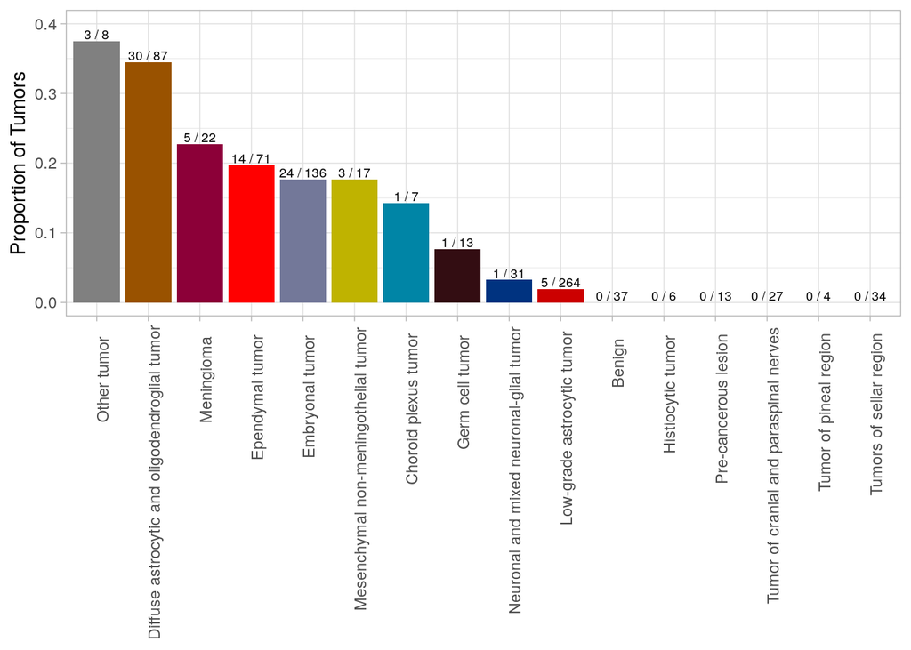

```r
p <- ggplot(chromoth_histology_summary, aes(x = display_group, y = prop, fill = hex_codes)) +
  geom_bar(stat = "identity") +
  geom_text(aes(label=labels), vjust=-0.2, size=2.5) +
  scale_fill_identity() +
  plot_options
p
```

```r
ggsave(file.path(plots_dir, "chromothripsis_proportion_by_histology.pdf"), p, width=7, height=7)
```

### Plot proportion of tumors stacked by low- or high-confidence chromothripsis

Proportion of tumors with at least one low- or high-confidence chromothripsis region (if a tumor has both low- and high-confidence regions, it will be grouped with high-confidence)

Note ggplot will output warning for 16 rows missing - these are the bars for “No Calls” which don’t display anyway, so it doesn’t matter

```
## Warning: Removed 16 rows containing missing values (geom_bar).
```

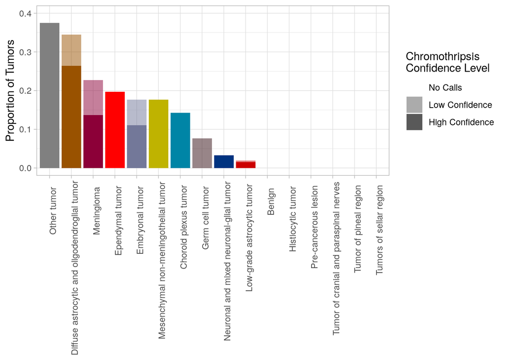

```r
# Scale alpha with confidence level - set "No Calls" as alpha=0 so the bar doesn't show
p <- ggplot(chromoth_histology, aes(x = display_group,
                                   fill = hex_codes,
                                   alpha = factor(any_regions,
                                                  levels=c("No Calls", "Low Confidence", "High Confidence")))) +
  geom_bar(position = "fill") +
  scale_fill_identity() +
  scale_alpha_manual(values=c(0, 0.5, 1), name="Chromothripsis\nConfidence Level") +
  plot_options
p
```

```r
ggsave(file.path(plots_dir, "chromothripsis_proportion_by_histology_withConfidence.pdf"), p, width=7, height=7)
```

```
## Warning: Removed 16 rows containing missing values (geom_bar).
```

### Plot proportion of tumors stacked by number of chromothripsis regions

Keep in mind that ShatterSeek only reports one chromothripsis region per chromosome, which is why the number of events per sample may seem low.

Note ggplot will output warning for 16 rows missing - these are the bars for “0” which don’t display anyway, so it doesn’t matter

```
## Warning: Removed 16 rows containing missing values (geom_bar).
```

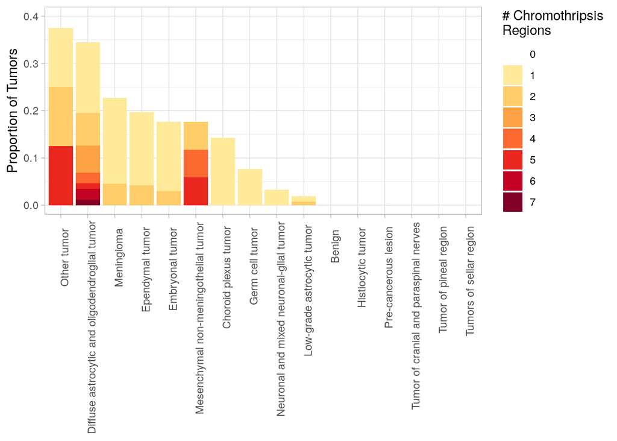

```r
# Define color scale for # chromothripsis regions, but set "0" as transparent so the bar doesn't show
# Pick number of colors based on max number of chromothripsis regions observed
max_regions <- max(chromoth_per_sample$count_regions_any_conf)
colors <- colorRampPalette(brewer.pal(9,"YlOrRd"))(max_regions+1)
colors[1] <- "#1C00ff00"

p <- ggplot(chromoth_histology, aes(x = display_group, fill = as.factor(count_regions_any_conf))) +
  geom_bar(position = "fill") +
  scale_fill_manual(values=colors, name="# Chromothripsis\nRegions") +
  plot_options
p
```

```r
ggsave(file.path(plots_dir, "chromothripsis_proportion_by_histology_withCount.pdf"), p, width=7, height=7)
```